# Pennsylvania Drug Overdose Dashboard

[figure not shown]

### Drug overdose deaths by county, Pennsylvania — 12 months ending March 2026

[interactive chart not shown]

> Darker red counties represent higher reported numbers of drug overdose deaths, while lighter yellow counties represent lower counts. Gray counties represent suppressed data, meaning their overdose death counts were withheld to protect privacy or because the counts were too small to report reliably. These missing values do not indicate that zero overdose deaths occurred.

### Drug overdose deaths over time, Pennsylvania and Philadelphia — 2020–2026

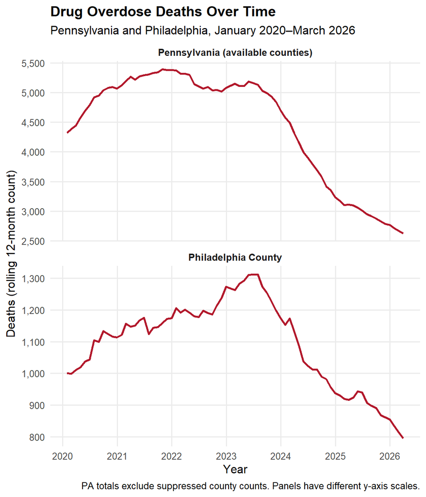

> We created a time series graph to examine changes in drug overdose deaths in Pennsylvania and Philadelphia County from 2020 to 2026. We used two separate graphs with different y-axis scales to make the trends easier to compare, since Pennsylvania has substantially more deaths than Philadelphia alone. The data represent rolling 12-month death counts.

> The graphs show that overdose deaths initially increased in both areas before declining. Pennsylvania reached its highest levels around 2022, while Philadelphia peaked around mid-2023. After these peaks, both areas experienced substantial decreases through early 2026. This suggests an overall improvement in overdose mortality trends, although the data do not establish what caused the decline. Additionally, statewide totals exclude suppressed county counts, meaning the reported totals may underestimate the actual number of deaths.

### About these data

- **Outcome and period:** Provisional county-level drug overdose death counts for rolling 12-month periods ending January 2020 through March 2026.
- **Population at risk:** Residents of Pennsylvania’s 67 counties.
- **Geography:** Pennsylvania counties, matched to 2020 U.S. Census county boundaries using five-digit FIPS/GEOID codes.
- **Method:** The map uses the latest available rolling 12-month count for each county. The time series sums available county counts by reporting month and shows Philadelphia County separately. Counts are not rates and are not adjusted for population.
- **Source:** [CDC National Center for Health Statistics, VSRR Provisional County-Level Drug Overdose Death Counts](https://data.cdc.gov/d/gb4e-yj24); county boundaries from the U.S. Census Bureau through the `tigris` R package.
- **Suppressed data:** At the latest reporting period, 24 counties have withheld values due to confidentiality rules for small counts. They remain missing, not zero.
- **Limitations:** Provisional figures may be revised. The Pennsylvania time-series totals omit suppressed county counts and therefore underestimate the statewide total. Raw counts are not appropriate for comparing counties’ per-person mortality risk.

### AI Use

> ChatGPT was used to assist with coding, debugging, and interpreting results throughout the development of my dashboard. Specifically, AI helped with cleaning and organizing the CDC overdose dataset, creating the choropleth map and time series, and explaining data suppression and limitations. I reviewed the generated code and visualizations to ensure they accurately represented the data.

````r
---
title: "Pennsylvania Drug Overdose Dashboard"
author: "Aaron Colon"
subtitle: "BSTA 374 · Milestone M1 · 2020–2026"
output:
  flexdashboard::flex_dashboard:
    orientation: columns
    vertical_layout: scroll
    source_code: embed
    self_contained: true
---

```{r setup, include=FALSE}
knitr::opts_chunk$set(echo = FALSE, message = FALSE, warning = FALSE)

library(tidyverse)
library(sf)
library(tigris)
library(lubridate)
library(leaflet)
library(ggplot2)
library(scales)

options(tigris_use_cache = TRUE)

# PART A — Data preparation. Keep this CSV in the repository's data/ folder.
# The values are rolling 12-month death counts, NOT individual-month counts.
# Parsing as character first preserves comma-formatted counts such as "1,000".
raw <- readr::read_csv(
  "data/VSRR_Provisional_County-Level_Drug_Overdose_Death_Counts_20261117.csv",
  col_types = readr::cols(
    FIPS = readr::col_character(),
    `Provisional Drug Overdose Deaths` = readr::col_character(),
    .default = readr::col_guess()
  ),
  show_col_types = FALSE
)

dat <- raw |>
  dplyr::filter(ST_ABBREV == "PA") |>
  dplyr::transmute(
    GEOID = stringr::str_pad(FIPS, width = 5, side = "left", pad = "0"),
    county = COUNTYNAME,
    month = lubridate::mdy(MonthEndingDate),
    deaths = readr::parse_number(`Provisional Drug Overdose Deaths`)
  )

latest_month <- max(dat$month, na.rm = TRUE)

# A single 12-month-ending observation for each county; do not add monthly
# entries because the 12-month windows overlap.
by_area <- dat |>
  dplyr::filter(month == latest_month) |>
  dplyr::select(GEOID, county, cases = deaths)

# The Pennsylvania series is the sum of DISCLOSED county counts, not the
# complete statewide count, because suppression prevents a full sum.
by_period <- dat |>
  dplyr::group_by(month) |>
  dplyr::summarise(
    cases = sum(deaths, na.rm = TRUE),
    n_suppressed = sum(is.na(deaths)),
    .groups = "drop"
  )

# 2020 Census cartographic county boundaries; initial knit needs internet.
pa_counties <- tigris::counties(
  state = "PA", cb = TRUE, year = 2020, progress_bar = FALSE
) |>
  dplyr::select(GEOID, NAME, geometry) |>
  sf::st_transform(4326)

my_map <- dplyr::left_join(pa_counties, by_area, by = "GEOID")

# Check a failed boundary join separately from suppressed counts.
join_missing <- dplyr::anti_join(
  sf::st_drop_geometry(pa_counties), by_area, by = "GEOID"
)
stopifnot(nrow(join_missing) == 0, nrow(my_map) == 67)

focus <- "Philadelphia"
focus_data <- dat |>
  dplyr::filter(county == focus) |>
  dplyr::transmute(month, cases = deaths)
```

Column {data-width=550}
-----------------------------------------------------------------------

### Drug overdose deaths by county, Pennsylvania — 12 months ending March 2026

```{r map, fig.height=6.5}
# PART B — A sequential palette for death COUNTS (not population-adjusted rates).
map_breaks <- unique(as.numeric(stats::quantile(
  my_map$cases, probs = seq(0, 1, 0.2), na.rm = TRUE
)))

pal <- leaflet::colorBin(
  palette = "YlOrRd",
  domain = my_map$cases,
  bins = map_breaks,
  na.color = "#D9D9D9",
  pretty = FALSE
)

my_map <- my_map |>
  dplyr::mutate(
    hover_text = dplyr::if_else(
      is.na(cases),
      paste0(NAME, " County: count suppressed"),
      paste0(
        NAME, " County: ",
        format(cases, big.mark = ",", trim = TRUE),
        " deaths (rolling 12-month total)"
      )
    )
  )

leaflet::leaflet(my_map) |>
  leaflet::addTiles() |>
  leaflet::addPolygons(
    color = "white",
    weight = 1,
    fillColor = ~pal(cases),
    fillOpacity = 0.85,
    label = ~hover_text,
    highlightOptions = leaflet::highlightOptions(
      color = "#333333", weight = 2, bringToFront = TRUE
    )
  ) |>
  leaflet::addLegend(
    position = "bottomright",
    pal = pal,
    values = ~cases,
    title = "Overdose deaths (rolling 12-month count)",
    opacity = 0.85,
    na.label = "Suppressed"
  )
```

> Darker red counties represent higher reported numbers of drug overdose deaths, while lighter yellow counties represent lower counts. Gray counties represent suppressed data, meaning their overdose death counts were withheld to protect privacy or because the counts were too small to report reliably. These missing values do not indicate that zero overdose deaths occurred.

Column {data-width=550}
-----------------------------------------------------------------------

### Drug overdose deaths over time, Pennsylvania and Philadelphia — 2020–2026

```{r time-series, fig.height=7}
# PART C — The Pennsylvania sum excludes counties with suppressed counts.
series_data <- dplyr::bind_rows(
  by_period |>
    dplyr::transmute(
      month, cases, area = "Pennsylvania (available counties)"
    ),
  focus_data |>
    dplyr::transmute(
      month, cases, area = "Philadelphia County"
    )
)

p <- ggplot2::ggplot(series_data, ggplot2::aes(x = month, y = cases)) +
  ggplot2::geom_line(color = "#B2182B", linewidth = 1.05, na.rm = TRUE) +
  ggplot2::facet_wrap(~area, ncol = 1, scales = "free_y") +
  ggplot2::scale_x_date(date_breaks = "1 year", date_labels = "%Y") +
  ggplot2::scale_y_continuous(labels = scales::label_comma()) +
  ggplot2::labs(
    title = "Drug Overdose Deaths Over Time",
    subtitle = "Pennsylvania and Philadelphia, January 2020–March 2026",
    x = "Year",
    y = "Deaths (rolling 12-month count)",
    caption = paste(
      "PA totals exclude suppressed county counts.",
      "Panels have different y-axis scales."
    )
  ) +
  ggplot2::theme_minimal(base_size = 12) +
  ggplot2::theme(
    strip.text = ggplot2::element_text(face = "bold"),
    plot.title = ggplot2::element_text(face = "bold"),
    panel.grid.minor = ggplot2::element_blank()
  )

p
```

> We created a time series graph to examine changes in drug overdose deaths in Pennsylvania and Philadelphia County from 2020 to 2026. We used two separate graphs with different y-axis scales to make the trends easier to compare, since Pennsylvania has substantially more deaths than Philadelphia alone. The data represent rolling 12-month death counts.

> The graphs show that overdose deaths initially increased in both areas before declining. Pennsylvania reached its highest levels around 2022, while Philadelphia peaked around mid-2023. After these peaks, both areas experienced substantial decreases through early 2026. This suggests an overall improvement in overdose mortality trends, although the data do not establish what caused the decline. Additionally, statewide totals exclude suppressed county counts, meaning the reported totals may underestimate the actual number of deaths.

### About these data

- **Outcome and period:** Provisional county-level drug overdose death counts for rolling 12-month periods ending January 2020 through March 2026.
- **Population at risk:** Residents of Pennsylvania's 67 counties.
- **Geography:** Pennsylvania counties, matched to 2020 U.S. Census county boundaries using five-digit FIPS/GEOID codes.
- **Method:** The map uses the latest available rolling 12-month count for each county. The time series sums available county counts by reporting month and shows Philadelphia County separately. Counts are not rates and are not adjusted for population.
- **Source:** [CDC National Center for Health Statistics, VSRR Provisional County-Level Drug Overdose Death Counts](https://data.cdc.gov/d/gb4e-yj24); county boundaries from the U.S. Census Bureau through the `tigris` R package.
- **Suppressed data:** At the latest reporting period, 24 counties have withheld values due to confidentiality rules for small counts. They remain missing, not zero.
- **Limitations:** Provisional figures may be revised. The Pennsylvania time-series totals omit suppressed county counts and therefore underestimate the statewide total. Raw counts are not appropriate for comparing counties' per-person mortality risk.

### AI Use
> ChatGPT was used to assist with coding, debugging, and interpreting results throughout the development of my dashboard. Specifically, AI helped with cleaning and organizing the CDC overdose dataset, creating the choropleth map and time series, and explaining data suppression and limitations. I reviewed the generated code and visualizations to ensure they accurately represented the data.
````